# EDA

### 1. Data Preparation

```r
#install.packages("tidyverse")
#install.packages("knitr")
library(tidyverse)
library(knitr)
library(readxl)
```

##### 1.1. list the excel file’s sheets

```r
excel_sheets('Credit_Risk6_final.xlsx')
```

```
## [1] "Scoring_Data"  "Training_Data"
```

##### 1.2. load the dataset

dataframe `df1` from ‘Training_Data’ sheet

```r
df1 <- read_excel('Credit_Risk6_final.xlsx', sheet = 'Training_Data')
str(df1)
```

```
## Classes 'tbl_df', 'tbl' and 'data.frame':    780 obs. of  14 variables:
##  $ ID                                  : num  1 2 3 4 5 6 7 8 9 10 ...
##  $ Checking Acct                       : chr  "No Acct" "0Balance" "0Balance" "0Balance" ...
##  $ Credit History                      : chr  "All Paid" "Current" "Current" "Current" ...
##  $ Loan Reason                         : chr  "Car New" "Car New" "Car New" "Furniture" ...
##  $ Savings Acct                        : chr  "Low" "Low" "No Acct" "No Acct" ...
##  $ Employment                          : chr  "Medium" "Short" "Long" "Long" ...
##  $ Personal Status                     : chr  "Single" "Divorced" "Divorced" NA ...
##  $ Housing                             : chr  "Own" "Own" "Own" "Own" ...
##  $ Job Type                            : chr  "Management" "Skilled" "Skilled" "Skilled" ...
##  $ Foreign National                    : chr  "No" "No" "No" "No" ...
##  $ Months since Checking Acct opened   : num  7 16 25 31 7 13 22 25 25 13 ...
##  $ Residence Time (In current district): num  3 2 2 4 4 2 3 4 4 4 ...
##  $ Age                                 : num  44 28 28 30 35 22 29 33 62 40 ...
##  $ Credit Standing                     : chr  "Good" "Bad" "Bad" "Good" ...
```

dataframe `df2` from ‘Scoring_Data’ sheet

```r
df2 <- read_excel('Credit_Risk6_final.xlsx', sheet = 'Scoring_Data')
str(df2)
```

```
## Classes 'tbl_df', 'tbl' and 'data.frame':    13 obs. of  13 variables:
##  $ ID                               : num  781 782 783 784 785 786 787 788 789 790 ...
##  $ Checking Acct                    : chr  "No Acct" "Low" "No Acct" "High" ...
##  $ Credit History                   : chr  "All Paid" "Current" "Current" "Current" ...
##  $ Loan Reason                      : chr  "Car New" "Small Appliance" "Small Appliance" "Business" ...
##  $ Savings Acct                     : chr  "MedHigh" "Low" "Low" "Low" ...
##  $ Employment                       : chr  "Short" "Medium" "Very Short" "Medium" ...
##  $ Personal Status                  : chr  "Single" "Single" "Divorced" "Single" ...
##  $ Housing                          : chr  "Rent" "Rent" "Own" "Rent" ...
##  $ Job Type                         : chr  "Unskilled" "Skilled" "Skilled" "Skilled" ...
##  $ Foreign National                 : chr  "No" "No" "No" "Yes" ...
##  $ Months since Checking Acct opened: num  11 37 13 16 9 49 37 12 19 16 ...
##  $ Residence Time                   : num  2 4 2 4 2 4 2 1 4 4 ...
##  $ Age                              : num  39 23 28 25 43 39 30 19 38 32 ...
```

##### 1.3 change columns’ names

dataframe `df1`

```r
names(df1)[names(df1) == 'ID'] <- 'id'
names(df1)[names(df1) == 'Checking Acct'] <- 'checking'
names(df1)[names(df1) == 'Credit History'] <- 'history'
names(df1)[names(df1) == 'Loan Reason'] <- 'loan_reason'
names(df1)[names(df1) == 'Savings Acct'] <- 'saving'
names(df1)[names(df1) == 'Employment'] <- 'employment'
names(df1)[names(df1) == 'Personal Status'] <- 'status'
names(df1)[names(df1) == 'Housing'] <- 'housing'
names(df1)[names(df1) == 'Job Type'] <- 'job'
names(df1)[names(df1) == 'Foreign National'] <- 'foreign'
names(df1)[names(df1) == 'Months since Checking Acct opened'] <- 'months'
names(df1)[names(df1) == 'Residence Time (In current district)'] <- 'residence'
names(df1)[names(df1) == 'Age'] <- 'age'
names(df1)[names(df1) == 'Credit Standing'] <- 'credit'
```

dataframe `df2`

```r
names(df2)[names(df2) == 'ID'] <- 'id'
names(df2)[names(df2) == 'Checking Acct'] <- 'checking'
names(df2)[names(df2) == 'Credit History'] <- 'history'
names(df2)[names(df2) == 'Loan Reason'] <- 'loan_reason'
names(df2)[names(df2) == 'Savings Acct'] <- 'saving'
names(df2)[names(df2) == 'Employment'] <- 'employment'
names(df2)[names(df2) == 'Personal Status'] <- 'status'
names(df2)[names(df2) == 'Housing'] <- 'housing'
names(df2)[names(df2) == 'Job Type'] <- 'job'
names(df2)[names(df2) == 'Foreign National'] <- 'foreign'
names(df2)[names(df2) == 'Months since Checking Acct opened'] <- 'months'
names(df2)[names(df2) == 'Residence Time'] <- 'residence'
names(df2)[names(df2) == 'Age'] <- 'age'
```

##### 1.4 checking duplications and overlaps

**a. checking column id in both `df1` & `df2`**  
building a function to check whether id’s vector is consecutive or not

```r
check_consecutive <- function(x){
  if(all(diff(x) == 1)){
    print('This is consecutive')
  }else{
    print('This is not consecutive')
    print('Positions are not consecutive')
    print(which(diff(x) != 1))
  }
}
```

```r
# checking the df1's id
check_consecutive(df1$id)
```

```
## [1] "This is consecutive"
```

```r
# checking the df2's id
check_consecutive(df2$id)
```

```
## [1] "This is consecutive"
```

**b. checking the ‘credit’ entry in dataframe df1**  
Since the credits are binary outcomes including ‘Good’ & ‘Bad’, the credit reflects a binomial distribution associated with percentage of ‘Good’ & percentage of ‘Bad’

```r
# percentage of the good credit
prop_good <- prop.table(table(df1$credit))[[2]]
prop_good
```

```
## [1] 0.5910256
```

```r
# percentage of the bad credit
prop_bad <- prop.table(table(df1$credit))[[1]]
prop_bad
```

```
## [1] 0.4089744
```

The probability of binomial distribution:
$$f(x) = {{}^n C_x} p^xq^{n-x}$$
$$p = 0.5910256$$
$$q = 0.4089744$$
Where n - the number of trials, p - the probability of ‘Good’, q - the probability of ‘Bad’
This report will look at consecutive credit values which are similar, i.e. a sequence of ‘Good’ or ‘Bad’. There is an assumption that all observations were recorded in chronological order refering to the order of the id. To specify the test, a level of 5% is given as the threshold. Any combinations, whose probabilities below the threshold, are considered suspicious.
For “Good” credit, the probability of having more than 6 consecutive entries will be less than the threshold
$$f(6) = {{}^6 C_6} p^6q^0 = 0.04262 < threshold$$
For “Bad” credit, the probability of having more than 4 consecutive entries will be less than the threshold
$$f(0) = {{}^4 C_0} p^0q^4 = 0.02798 < threshold$$

```r
# getting the lengths of consecutive credits which are similar
consecutive_credit <- rle(df1$credit)
credit_freq <- consecutive_credit[[1]]
credit_value <- consecutive_credit[[2]]
# identify the ids positions where consecutive similar credits start
id_start <- c(1, cumsum(consecutive_credit[[1]]) + 1)
id_start <- id_start[1:length(id_start)-1]
# identify the ids positions where consecutive similar credits end
id_end <- id_start + consecutive_credit[[1]] - 1
# calculate chance of events associated with consecutive similar credits
chance <- c()
for(i in 1:length(id_start)){
  if(credit_value[i] == "Good"){
    chance <- c(chance, prop_good^credit_freq[i]*100)
  }else{
    chance <- c(chance, prop_bad^credit_freq[i]*100)
  }
}
# creating a dataframe for suspicious entries
# i.e. number of consecutive credit entries are greater than 6
frame_a <- data.frame(id_start, id_end, credit_freq, credit_value, chance)
colnames(frame_a) <- c('id_start', 'id_end', 'frequency', 'value','chance_in_percentage')
good_entry_limit <- frame_a %>%
  filter(value == 'Good') %>%
  filter(frequency >= 6)
bad_entry_limit <- frame_a %>%
  filter(value == 'Bad') %>%
  filter(frequency >= 4)
suspicious_entry <- bind_rows(good_entry_limit, bad_entry_limit)
suspicious_entry <- suspicious_entry %>% arrange(id_start)
suspicious_entry
```

```
##    id_start id_end frequency value chance_in_percentage
## 1         4     10         7  Good         2.519093e+00
## 2        28     35         8  Good         1.488849e+00
## 3        73     79         7  Good         2.519093e+00
## 4       124    127         4   Bad         2.797592e+00
## 5       144    150         7  Good         2.519093e+00
## 6       177    184         8  Good         1.488849e+00
## 7       210    215         6  Good         4.262240e+00
## 8       233    240         8  Good         1.488849e+00
## 9       279    284         6  Good         4.262240e+00
## 10      303    308         6   Bad         4.679253e-01
## 11      312    329        18   Bad         1.024541e-05
## 12      341    346         6  Good         4.262240e+00
## 13      347    350         4   Bad         2.797592e+00
## 14      376    380         5   Bad         1.144143e+00
```

[output cut: 21 more lines]

**CONCLUSION 1:** considering the theoretical probability of binomial distribution and the assumption of all the entries are recorded in the chronological order refering to the order of the id, in total, there are **35** cases that suspicious entries, which include their ids from start to end in their sequences, are revealed. Noticeably, 25 consecutive “Good” credit entries and up to 18 “Bad” ones are identified. Statistically speaking, those cases are extremly rare in an unbiased theoretical setting given by the overall binominal probabilities of the “Good” and "Bad. To a certain extent, this finding might question the realibility of the grading system which comprised both automatic process and manual endevours by human.  
**d. checking duplications in all observations regardless of ids**  
The upcoming predictive models will be built upon observations except for ids. Therefore, it is necessary to check whether there are any duplications in the dataset `df1` & `df2`.

```r
# creating a vector containing rows are duplicated with other rows in the dataset df1
a <- duplicated(df1[,2:14])
row_dups <- df1$id[a]
# print all the ids having similar rows in the dataset df1
for(j in row_dups){
  for(i in 1:nrow(df1)){
    if(j != i){
      if(identical(df1[j,2:14], df1[i, 2:14])){
        cat('\n In the dataset df1, the id number',df1[j,1]$id, 'is having similar row to the id number',df1[i,1]$id)
      }
    }
  }
}
```

```
##
##  In the dataset df1, the id number 314 is having similar row to the id number 249
##  In the dataset df1, the id number 317 is having similar row to the id number 48
##  In the dataset df1, the id number 321 is having similar row to the id number 142
##  In the dataset df1, the id number 322 is having similar row to the id number 138
##  In the dataset df1, the id number 329 is having similar row to the id number 290
##  In the dataset df1, the id number 332 is having similar row to the id number 284
##  In the dataset df1, the id number 334 is having similar row to the id number 278
##  In the dataset df1, the id number 335 is having similar row to the id number 276
##  In the dataset df1, the id number 337 is having similar row to the id number 256
##  In the dataset df1, the id number 338 is having similar row to the id number 252
##  In the dataset df1, the id number 339 is having similar row to the id number 244
##  In the dataset df1, the id number 355 is having similar row to the id number 144
##  In the dataset df1, the id number 356 is having similar row to the id number 143
##  In the dataset df1, the id number 357 is having similar row to the id number 132
##  In the dataset df1, the id number 359 is having similar row to the id number 129
##  In the dataset df1, the id number 367 is having similar row to the id number 80
##  In the dataset df1, the id number 371 is having similar row to the id number 43
##  In the dataset df1, the id number 372 is having similar row to the id number 36
##  In the dataset df1, the id number 374 is having similar row to the id number 30
##  In the dataset df1, the id number 375 is having similar row to the id number 29
##  In the dataset df1, the id number 376 is having similar row to the id number 22
##  In the dataset df1, the id number 377 is having similar row to the id number 14
##  In the dataset df1, the id number 402 is having similar row to the id number 87
##  In the dataset df1, the id number 403 is having similar row to the id number 51
##  In the dataset df1, the id number 404 is having similar row to the id number 45
##  In the dataset df1, the id number 405 is having similar row to the id number 40
##  In the dataset df1, the id number 406 is having similar row to the id number 27
##  In the dataset df1, the id number 407 is having similar row to the id number 17
##  In the dataset df1, the id number 408 is having similar row to the id number 62
##  In the dataset df1, the id number 409 is having similar row to the id number 192
##  In the dataset df1, the id number 422 is having similar row to the id number 272
##  In the dataset df1, the id number 423 is having similar row to the id number 218
##  In the dataset df1, the id number 424 is having similar row to the id number 210
##  In the dataset df1, the id number 425 is having similar row to the id number 202
##  In the dataset df1, the id number 426 is having similar row to the id number 194
##  In the dataset df1, the id number 427 is having similar row to the id number 147
##  In the dataset df1, the id number 428 is having similar row to the id number 146
##  In the dataset df1, the id number 430 is having similar row to the id number 83
##  In the dataset df1, the id number 431 is having similar row to the id number 79
```

[output cut: 90 more lines]

```
##  In the dataset df1, the id number 722 is having similar row to the id number 182
##  In the dataset df1, the id number 725 is having similar row to the id number 177
##  In the dataset df1, the id number 727 is having similar row to the id number 169
##  In the dataset df1, the id number 732 is having similar row to the id number 154
##  In the dataset df1, the id number 733 is having similar row to the id number 150
##  In the dataset df1, the id number 734 is having similar row to the id number 149
##  In the dataset df1, the id number 735 is having similar row to the id number 148
##  In the dataset df1, the id number 736 is having similar row to the id number 145
##  In the dataset df1, the id number 737 is having similar row to the id number 139
##  In the dataset df1, the id number 738 is having similar row to the id number 136
##  In the dataset df1, the id number 739 is having similar row to the id number 126
##  In the dataset df1, the id number 741 is having similar row to the id number 123
##  In the dataset df1, the id number 759 is having similar row to the id number 49
##  In the dataset df1, the id number 775 is having similar row to the id number 127
##  In the dataset df1, the id number 776 is having similar row to the id number 124
```

```r
# the number of duplications in the dataset df1
cat('Number of duplications in the dataset df1:',length(row_dups))
```

```
## Number of duplications in the dataset df1: 142
```

```r
# for example, id 470 has similar row to id 7
df1[df1$id == 470,]
```

```
## # A tibble: 1 x 14
##      id checking history loan_reason saving employment status housing job
##   <dbl> <chr>    <chr>   <chr>       <chr>  <chr>      <chr>  <chr>   <chr>
## 1   470 0Balance All Pa… Car New     Low    Long       Marri… Own     Skil…
## # … with 5 more variables: foreign <chr>, months <dbl>, residence <dbl>,
## #   age <dbl>, credit <chr>
```

```r
df1[df1$id == 7,]
```

```
## # A tibble: 1 x 14
##      id checking history loan_reason saving employment status housing job
##   <dbl> <chr>    <chr>   <chr>       <chr>  <chr>      <chr>  <chr>   <chr>
## 1     7 0Balance All Pa… Car New     Low    Long       Marri… Own     Skil…
## # … with 5 more variables: foreign <chr>, months <dbl>, residence <dbl>,
## #   age <dbl>, credit <chr>
```

checking duplications in the dataset df2

```r
b <- duplicated(df2[,2:13])
b
```

```
##  [1] FALSE FALSE FALSE FALSE FALSE FALSE FALSE FALSE FALSE FALSE FALSE
## [12] FALSE FALSE
```

there is no duplication in the dataset df2

checking any overlap between df1 & df2 regardless of the ids columns, i.e. checking whether any new observations are from the past observations

```r
for(i in 1:nrow(df2)){
  for(j in 1:nrow(df1)){
    if(identical(df2[i,2:13], df1[j,2:13])){
      cat('\nThe id', df2[i,1]$id,'in dataset df2 is having similar row to the id', df1[j,1]$id, 'in dataset df1')
    }
  }
}
```

```
##
## The id 782 in dataset df2 is having similar row to the id 607 in dataset df1
## The id 783 in dataset df2 is having similar row to the id 603 in dataset df1
```

```r
# for example, id 782 in dataset df2 is similar to the id 607 in dataset df1
df2[df2$id == 782,]
```

```
## # A tibble: 1 x 13
##      id checking history loan_reason saving employment status housing job
##   <dbl> <chr>    <chr>   <chr>       <chr>  <chr>      <chr>  <chr>   <chr>
## 1   782 Low      Current Small Appl… Low    Medium     Single Rent    Skil…
## # … with 4 more variables: foreign <chr>, months <dbl>, residence <dbl>,
## #   age <dbl>
```

```r
df1[df1$id == 607,]
```

```
## # A tibble: 1 x 14
##      id checking history loan_reason saving employment status housing job
##   <dbl> <chr>    <chr>   <chr>       <chr>  <chr>      <chr>  <chr>   <chr>
## 1   607 Low      Current Small Appl… Low    Medium     Single Rent    Skil…
## # … with 5 more variables: foreign <chr>, months <dbl>, residence <dbl>,
## #   age <dbl>, credit <chr>
```

```r
# removing duplications in dataset df1
df1 <- df1[-row_dups,]
```

**CONCLUSION 2:** In the dataframe df1, there are 142 duplications. It accounts for 18% of the dataset with 780 observations. It is necessary to remove those duplications which might effect the reliability of predictive models.  
In the dataframe df2, there is no duplication yet the overlap of observations from the dataframe df1. To be more specific, the df2’s observations whose ids are 782 & 783 are having similar inputs as df1’s observations whose ids are 607 & 603 respectively. It could be a good reference for checking the predictive models’ accuracy. The future predicted credit values of ids 782 & 783 in dataframe df2 should be “Good” given by the df1’s observation with the ids 607 & 603.

##### 1.5 checking categorical variables

**a. factorise columns whose classes are characters**

```r
# df1
for(i in 2:ncol(df1)){
  if(is.character(df1[[i]])){
    df1[[i]] <- as.factor(df1[[i]])
  }
}
# df2
for(i in 2:ncol(df2)){
  if(is.character(df2[[i]])){
    df2[[i]] <- as.factor(df2[[i]])
  }
}
```

**b. changing level’s name from ‘0Balance’ to ‘No Balance’ in the checking column**

```r
# df1
levels(df1$checking)[levels(df1$checking) == '0Balance'] <- 'No Balance'
# df2
levels(df2$checking)[levels(df2$checking) == '0Balance'] <- 'No Balance'
```

**c. checking missing values for each categorical variable**

```r
for(i in 2:ncol(df1)){
  if(is.factor(df1[[i]])){
    cat('\n','This is the column', names(df1[i]), '\n')
    cat('No. of missing values', sum(is.na(df1[[i]])), '\n')
  }
}
```

```
##
##  This is the column checking
## No. of missing values 0
##
##  This is the column history
## No. of missing values 0
##
##  This is the column loan_reason
## No. of missing values 0
##
##  This is the column saving
## No. of missing values 0
##
##  This is the column employment
## No. of missing values 33
##
##  This is the column status
## No. of missing values 6
##
##  This is the column housing
## No. of missing values 5
##
##  This is the column job
## No. of missing values 0
##
##  This is the column foreign
## No. of missing values 0
##
##  This is the column credit
## No. of missing values 0
```

##### 1.6. checking numeric columns

```r
# checking missing values
for(i in 2:ncol(df1)){
  if(is.numeric(df1[[i]])){
    cat('\n','This is the column', names(df1[i]), '\n')
    cat('No. of missing values', sum(is.na(df1[[i]])), '\n')
  }
}
```

```
##
##  This is the column months
## No. of missing values 0
##
##  This is the column residence
## No. of missing values 0
##
##  This is the column age
## No. of missing values 0
```

##### 1.7 dealing with missing values

```r
# instruction: https://cran.r-project.org/web/packages/mice/mice.pdf
# install.packages('mice')
library(mice)
```

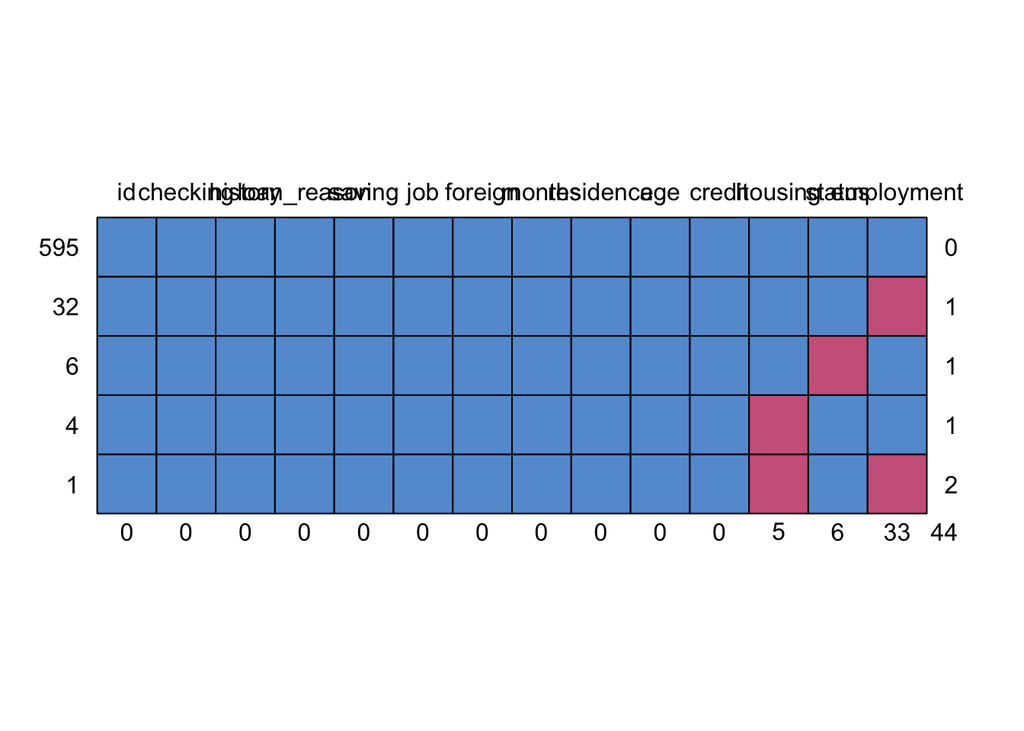

```
##     id checking history loan_reason saving job foreign months residence
## 595  1        1       1           1      1   1       1      1         1
## 32   1        1       1           1      1   1       1      1         1
## 6    1        1       1           1      1   1       1      1         1
## 4    1        1       1           1      1   1       1      1         1
## 1    1        1       1           1      1   1       1      1         1
##      0        0       0           0      0   0       0      0         0
##     age credit housing status employment
## 595   1      1       1      1          1  0
## 32    1      1       1      1          0  1
## 6     1      1       1      0          1  1
## 4     1      1       0      1          1  1
## 1     1      1       0      1          0  2
##       0      0       5      6         33 44
```

```r
#visualising the missing-data matrix
md.pattern(df1)
```

```r
# imputing the missing data
impute <- mice(df1[,2:14], m=5, seed = 696)   # m: Number of multiple imputations
print(impute)   # for catogerical variables having missing values, i.e. employment, status & housing, multinomial logistic regression is applied
```

```
## Class: mids
## Number of multiple imputations:  5
## Imputation methods:
##    checking     history loan_reason      saving  employment      status
##          ""          ""          ""          ""   "polyreg"   "polyreg"
##     housing         job     foreign      months   residence         age
##   "polyreg"          ""          ""          ""          ""          ""
##      credit
##          ""
## PredictorMatrix:
##             checking history loan_reason saving employment status housing
## checking           0       1           1      1          1      1       1
## history            1       0           1      1          1      1       1
## loan_reason        1       1           0      1          1      1       1
## saving             1       1           1      0          1      1       1
## employment         1       1           1      1          0      1       1
## status             1       1           1      1          1      0       1
##             job foreign months residence age credit
## checking      1       1      1         1   1      1
## history       1       1      1         1   1      1
## loan_reason   1       1      1         1   1      1
## saving        1       1      1         1   1      1
## employment    1       1      1         1   1      1
## status        1       1      1         1   1      1
```

```r
# complete data
df1 <- bind_cols(as.data.frame(df1$id), complete(impute, 1))
names(df1)[names(df1) == 'df1$id'] <- 'id'
str(df1)
```

```
## 'data.frame':    638 obs. of  14 variables:
##  $ id         : num  1 2 3 4 5 6 7 8 9 10 ...
##  $ checking   : Factor w/ 4 levels "No Balance","High",..: 4 1 1 1 4 3 1 3 1 4 ...
##  $ history    : Factor w/ 5 levels "All Paid","Bank Paid",..: 1 4 4 4 1 4 1 2 1 5 ...
##  $ loan_reason: Factor w/ 10 levels "Business","Car New",..: 2 2 2 5 10 2 2 4 3 3 ...
##  $ saving     : Factor w/ 5 levels "High","Low","MedHigh",..: 2 2 5 5 5 4 2 2 2 2 ...
##  $ employment : Factor w/ 6 levels "Long","Medium",..: 2 4 1 1 1 6 1 2 1 4 ...
##  $ status     : Factor w/ 3 levels "Divorced","Married",..: 3 1 1 3 3 1 2 1 3 2 ...
##  $ housing    : Factor w/ 3 levels "Other","Own",..: 2 2 2 2 1 2 2 1 2 3 ...
##  $ job        : Factor w/ 4 levels "Management","Skilled",..: 1 2 2 2 2 4 2 4 2 2 ...
##  $ foreign    : Factor w/ 2 levels "No","Yes": 1 1 1 1 2 1 2 1 2 2 ...
##  $ months     : num  7 16 25 31 7 13 22 25 25 13 ...
##  $ residence  : num  3 2 2 4 4 2 3 4 4 4 ...
##  $ age        : num  44 28 28 30 35 22 29 33 62 40 ...
##  $ credit     : Factor w/ 2 levels "Bad","Good": 2 1 1 2 2 2 2 2 2 2 ...
```

##### 1.8 export csv files from dataframes df1 & df2

```r
# write.csv(df1, 'df1.csv', row.names = FALSE)
# write.csv(df2, 'df2.csv', row.names = FALSE)
```

### 2. EDA

```r
# setting positions of numeric variables and categorical variables
nume_pos <- c(11,12,13)
cate_pos <- c(2,3,4,5,6,7,8,9,10,14)
```

##### 2.1 investigating correlations among variables

**a.correlations among numeric variables**

```r
# create a dataframe having numeric variables
df1numeric <- df1[,nume_pos]
# building correlation matrix among variables
cor.mat <- cor(df1numeric, use = 'complete.obs')
# building p-value matrix among variables
cor.mtest <- function(mat, ...) {
  mat <- as.matrix(mat)
  n <- ncol(mat)
  p.mat<- matrix(NA, n, n)
  diag(p.mat) <- 0
  for (i in 1:(n - 1)) {
    for (j in (i + 1):n) {
      tmp <- cor.test(mat[, i], mat[, j], ...)
      p.mat[i, j] <- p.mat[j, i] <- tmp$p.value
    }
  }
  colnames(p.mat) <- rownames(p.mat) <- colnames(mat)
  p.mat
}
p.mat <- cor.mtest(df1numeric)
```

```r
# install.packages("corrplot")
# instruction: http://www.sthda.com/english/wiki/visualize-correlation-matrix-using-correlogram
library(corrplot)
```

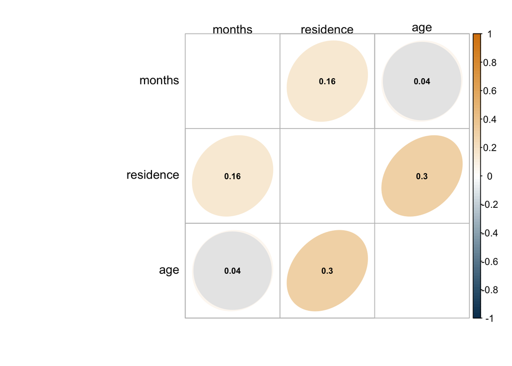

```r
# plotting correlation matrix
col1 <- colorRampPalette(c("#083c5d",'white', "#d98310"))
corrplot(cor.mat,
         method = 'ellipse',
         # choosing lower half of the corr. plot
         # type = 'lower',
         # add the correlation
         addCoef.col = 'black', number.cex = 0.7,
         # changing the axis's color
         tl.col="black",
         tl.srt=0,
         # dropping the correlation between a variabe with itself
         diag=F,
         # color grey indicates the cells with insignificant level of p-value being greater than 0.01
         p.mat = p.mat, sig.level = 0.01, pch.col = 'grey91', pch.cex = 14, pch = 19,
         col = col1(100))
```

**CONCLUSION 3:** Using Pearson’s cofficent to identify correlation between numeric variables, the greater the value is shown in graph above, the stronger the correlations between numeric variables are. There is a positively weak correlation between variable residence and variable age. The correlation between residence and months is fairly weak. There is not enough evidence to identify any relationship between age and months.  
NB. The grey circles in the graph above indicates there is not enough evidence where p-value is bigger than significance level (1%) to identify any correlation between variables  
**b. correlations among categorical variables chi squared test**

```r
# install.packages('greybox')
# instruction: https://rdrr.io/cran/greybox/man/cramer.html
library(greybox)
```

```r
# create a dataframe having categorical variables
df1cate <- df1[,cate_pos]
```

```r
# create chi-square matrix & corresponding p-value matrix
chi_elements <- c()
pchi_elements <- c()
for(i in 1:length(df1cate)){
  for(j in 1:length(df1cate)){
    chi <- cramer(df1cate[[i]], df1cate[[j]], use = 'complete.obs')
    chi_elements <- c(chi_elements, chi$value)
    pchi_elements <- c(pchi_elements, chi$p.value)
  }
}
chi.mat <- matrix(chi_elements,
                  nrow = length(df1cate),
                  dimnames = list(names(df1cate), names(df1cate)))
pchi.mat <- matrix(pchi_elements,
                   nrow = length(df1cate),
                   dimnames = list(names(df1cate), names(df1cate)))
```

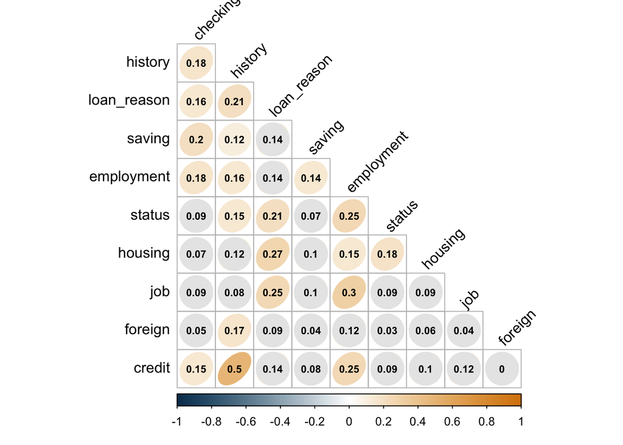

```r
# plotting chi-square matrix
col1 <- colorRampPalette(c("#083c5d",'white', "#d98310"))
corrplot(chi.mat,
         method = 'ellipse',
         # choosing lower half of the corr. plot
         type = 'lower',
         # add the correlation
         addCoef.col = 'black', number.cex = 0.7,
         # changing the axis's color
         tl.col="black",
         tl.srt=45,
         # dropping the correlation between a variabe with itself
         diag=F,
         # grey coloring the cells with insignificant level of p-value being greater than 0.01
         p.mat = pchi.mat, sig.level = 0.01, pch.col = 'grey91', pch.cex = 4.8, pch = 19,
         col = col1(100))
```

**CONCLUSION 4:** Using chi-square test to identify any association between categorical variables, the bigger values are shown in graph above, the stronger associations between categorical variables are. With regards to the response variable credit, there is a moderately strong association between the variable with history variable. Additionally, the variable is having some weak associations with employment and checking. This crucial finding is a good reference for understanding predictive models whose important variables might be likely to be the history, employment and probaly checking variables.  
NB. The grey circles in the graph above indicates there is not enough evidence where p-value is bigger than significance level (1%) to identify any association between variables

**c. intraclass correlations between categorical variables vs numerical variables (ANOVA)**

```r
# instruction: https://cran.r-project.org/web/packages/ICC/ICC.pdf
# install.packages('ICC')
library(ICC)
```

```r
# create intraclass coefficient matrix and corresponding p-value matrix
intra_elements <- c()
p.intra_elements <- c()
for(i in nume_pos){
  for(j in cate_pos){
    # create a vector of intraclass coefficients
    ano <- ICCest(df1[[j]], df1[[i]], alpha = 0.01)
    intra_elements <- c(intra_elements, ano$ICC)
    # create a vector of p-values
    anova_test <- aov(df1[[i]] ~ df1[[j]])
    p.intra <- summary(anova_test)[[1]][["Pr(>F)"]][1]
    p.intra_elements <- c(p.intra_elements, p.intra)
  }
}
intra.mat <- matrix(intra_elements,
                    nrow = length(nume_pos),
                    byrow = TRUE,
                    dimnames = list(names(df1numeric), names(df1cate)))
p.intra.mat <- matrix(p.intra_elements,
                      nrow = length(nume_pos),
                      byrow = TRUE,
                      dimnames = list(names(df1numeric), names(df1cate)))
```

```r
library(reshape2)
```

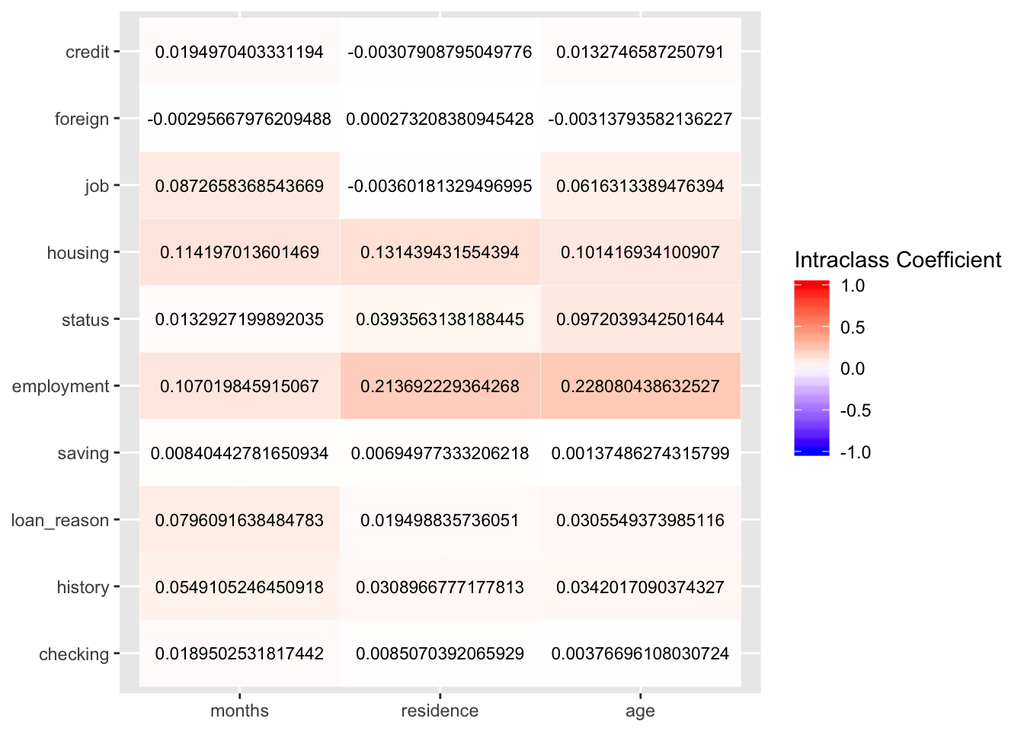

```r
melted_cormat1 <- melt(intra.mat)
ggplot(data = melted_cormat1, aes(x=Var1, y=Var2, fill=value)) +
  geom_tile(color = "white") +
  scale_fill_gradient2(low = "blue", high = "red", mid = "white",
   midpoint = 0, limit = c(-1,1), space = "Lab",
    name="Intraclass Coefficient") +
  geom_text(aes(Var1, Var2, label = value), color = "black", size = 3) +
  theme(axis.title.x = element_blank(), axis.title.y = element_blank())
```

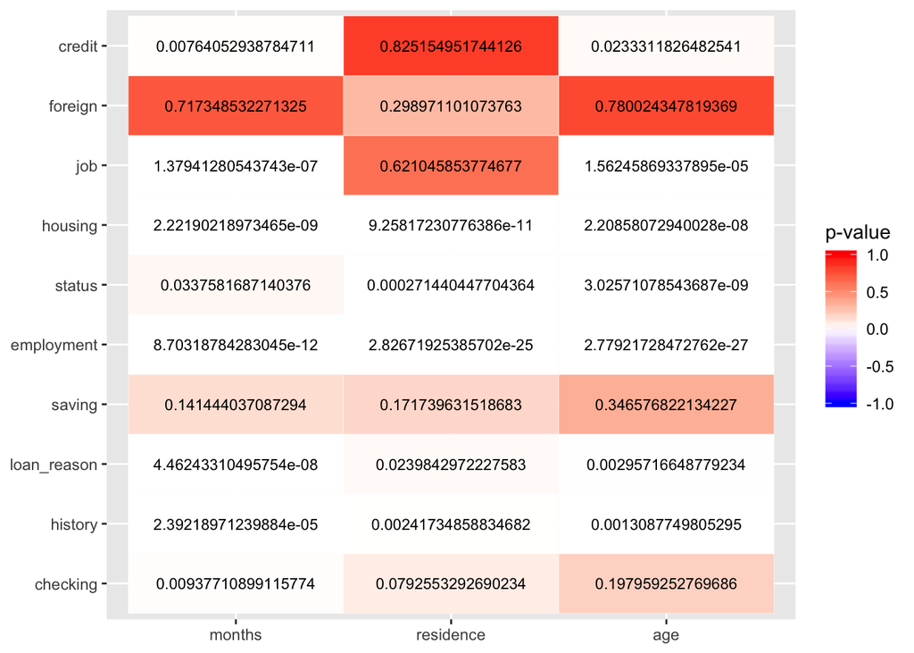

```r
melted_cormat2 <- melt(p.intra.mat)
ggplot(data = melted_cormat2, aes(x=Var1, y=Var2, fill=value)) +
  geom_tile(color = "white") +
  scale_fill_gradient2(low = "blue", high = "red", mid = "white",
   midpoint = 0, limit = c(-1,1), space = "Lab",
    name="p-value") +
  geom_text(aes(Var1, Var2, label = value), color = "black", size = 3) +
  theme(axis.title.x = element_blank(), axis.title.y = element_blank())
```

**CONCLUSION 5:** Using analysis of variance (ANOVA) to identify any variation between groups in a numeric variable, i.e. the relationship between a numeric variable and a categorical variable, the bigger the intraclass coefficients are shown in graph above, the stronger relationships between categorical and numeric variables are. With regards to the response variable credit, there are very weak relationships between the variable with other numeric variables including months, residence and age.

##### 2.1 Visualisations

The following visualisations are based upon previous conclusions regarding correlation/association between credit variable with 1) history & 2) employment  
**a. Univariate visualisation - Credit**

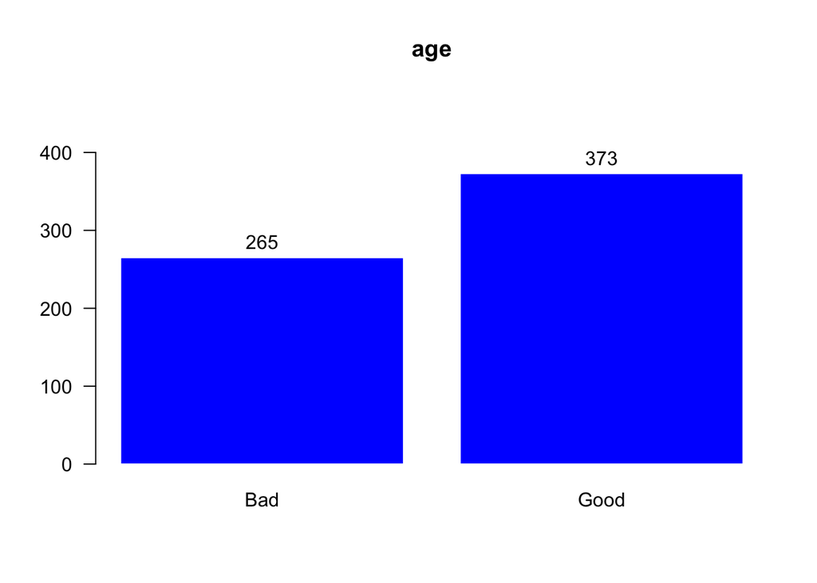

```r
df <- as.data.frame(table(df1$credit))
bp <- barplot(df[[2]],
              names.arg=df[[1]],
              las = 1,
              border = F,
              ylim = c(0,max(df[[2]]) + 100),
              main = names(df1[i]),
              col = 'blue',
              cex.names = 1)
text(bp, df[[2]] + 20, labels = df[[2]], cex=1, col = 'black')
```

**CONCLUSION 6:** The barplot above shows the numer of each class in credit. The bad credit accounts for 41% of the total observations. Meanwhile, the good credit accounts for 59%. Besides, it might not reveal a significant class imbalance between good credit and bad one. However, carefully selecting performance metrics for future predictive models are necessary because the imperfect division of the good and the bad might have a certain effect on those metrics to a certain extent.  
**b. Bivariate visualisation - Credit vs history & employment**

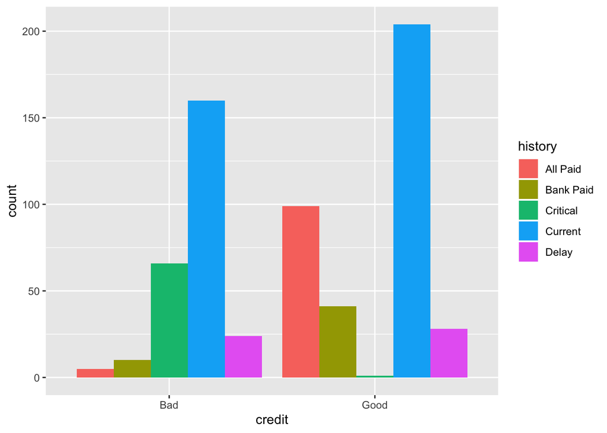

```r
ggplot(df1, aes(x=credit, fill=history)) +
  geom_bar(position = 'dodge') +
  theme(axis.text.x = element_text(angle = 0))
```

**CONCLUSION 7:** The barplot above shows a striking difference between how the bad credit and the good one are grouped into different values of history. To be more precise, the majority of critical history falls into the bad credit. Meanwhile, most of the paid history belongs to the good credit.

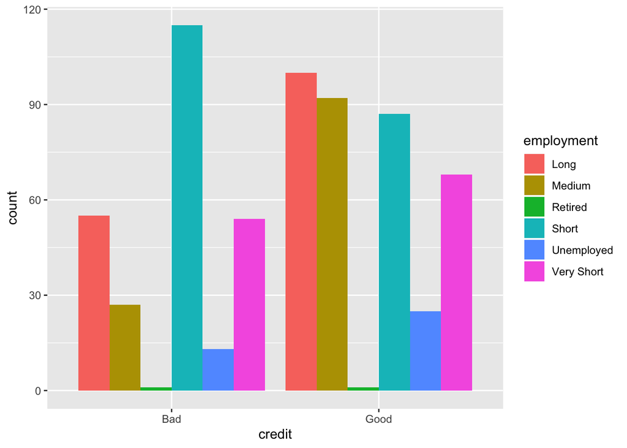

```r
ggplot(df1, aes(x=credit, fill=employment)) +
  geom_bar(position = 'dodge') +
  theme(axis.text.x = element_text(angle = 0))
```

**CONCLUSION 8:** The barplot above indicates a significant number of short employment falling into the bad credit. The short employment is also the dominant value in the employment variable.  
**c. Multivariate visualisation - Credit vs history & months**

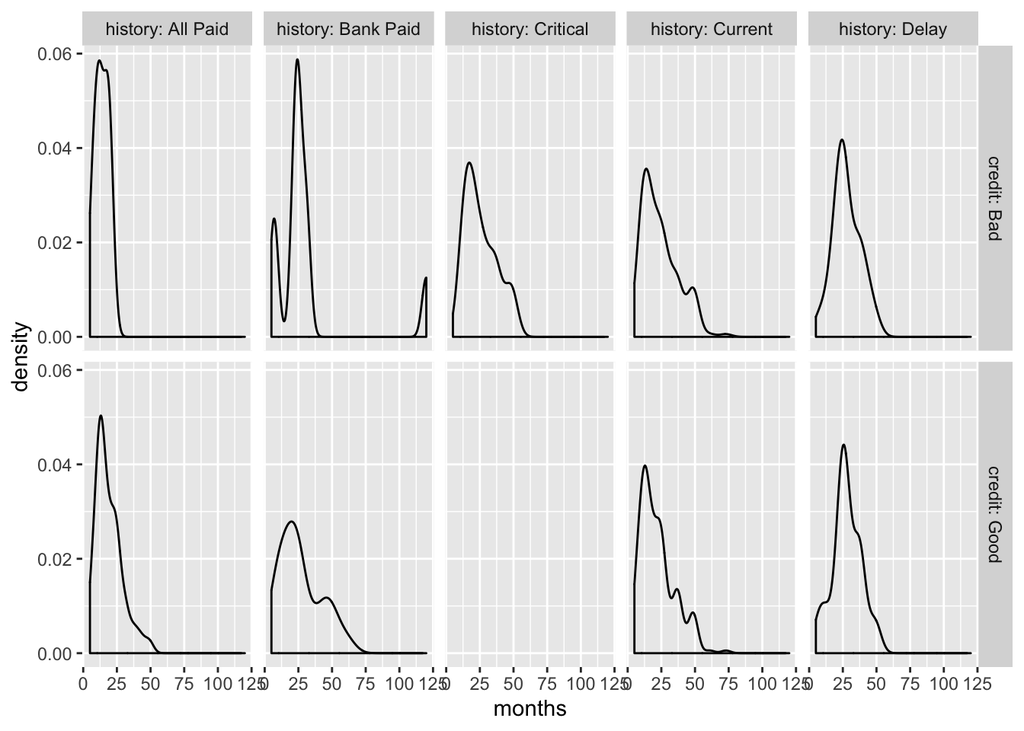

```r
ggplot(df1, aes(x=months)) +
  geom_density() +
  facet_grid(credit ~ history, labeller = label_both)
```